# Color Tests for BRE

2024-05-21

### Possible color scheme reccomendations for new BRE R package and all visuals

#### Single Sequential colors:

- These would be for likert scale items that have a single order like “Minimal” to “Extensive”
- `BRE Blue` is the blue color for our branding to white, dropping the lightest shades.

##### Seven point scales:

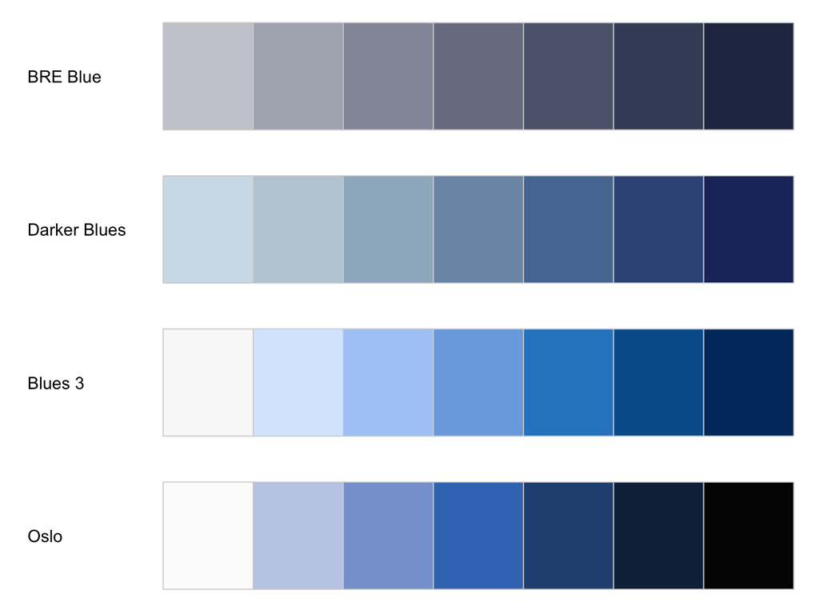

##### Five point scales:

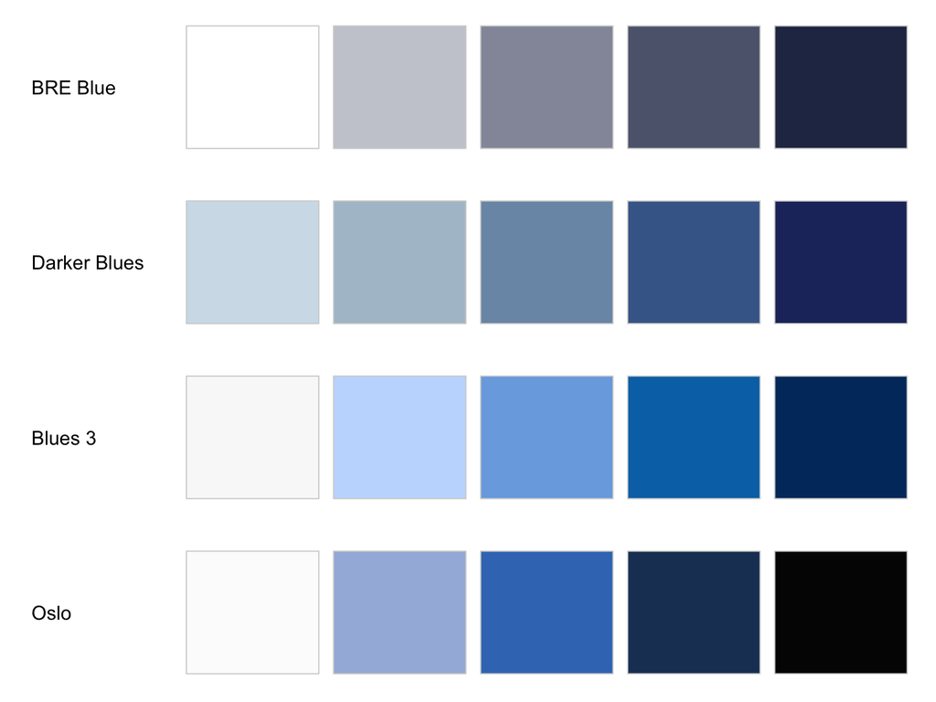

#### Single Sequential (Multi-hue) colors:

- These would be for likert scale items that have a single order like “Minimal” to “Extensive”, but have a bit more color to break up
- The `Viridis` would also work for qualitative/categories

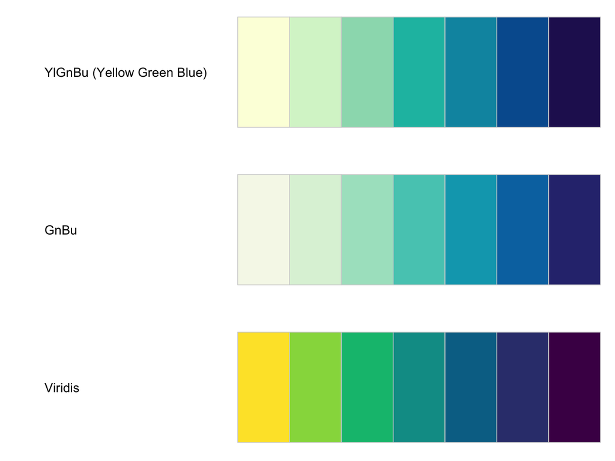

#### Diverging colors:

- These would mostly be for likert scale items that are folded scales like ‘Strongly Disagee’ to ‘Strongly Agree’.
- The `Cividis` palette could work for any type of likert scale items stacked bar charts.

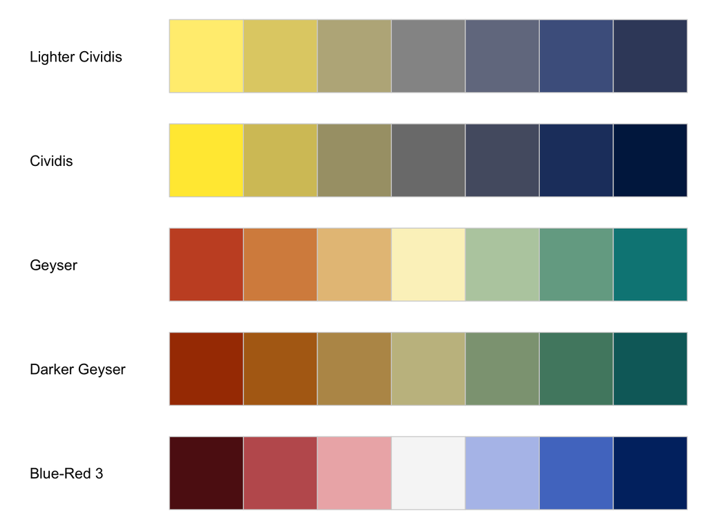

### All Color-blind Friendly Palettes:

#### My recommendations:

- “Cividis” as the default sequential color scale of likert items like: Minimal, Slight, Moderate, Good, Extensive- that are not folded/go in a single direction.
- “Blue-Red 3” as the default sequential color scale of likert items that are folded/have a positive and negative connotation like: Strongly disagree to Strongly Agree
- “Viridis” or “Okabe-Ito” as the default qualitative/categorical scales (e.g. demographics, gender, role).

##### Colorblind Friendly Swatches for **3** Items

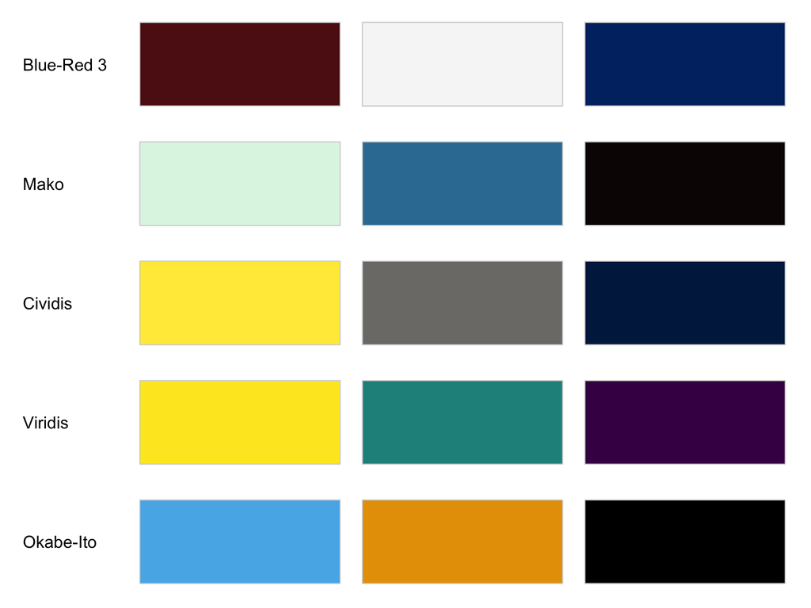

##### Colorblind Friendly Swatches for **4** Items

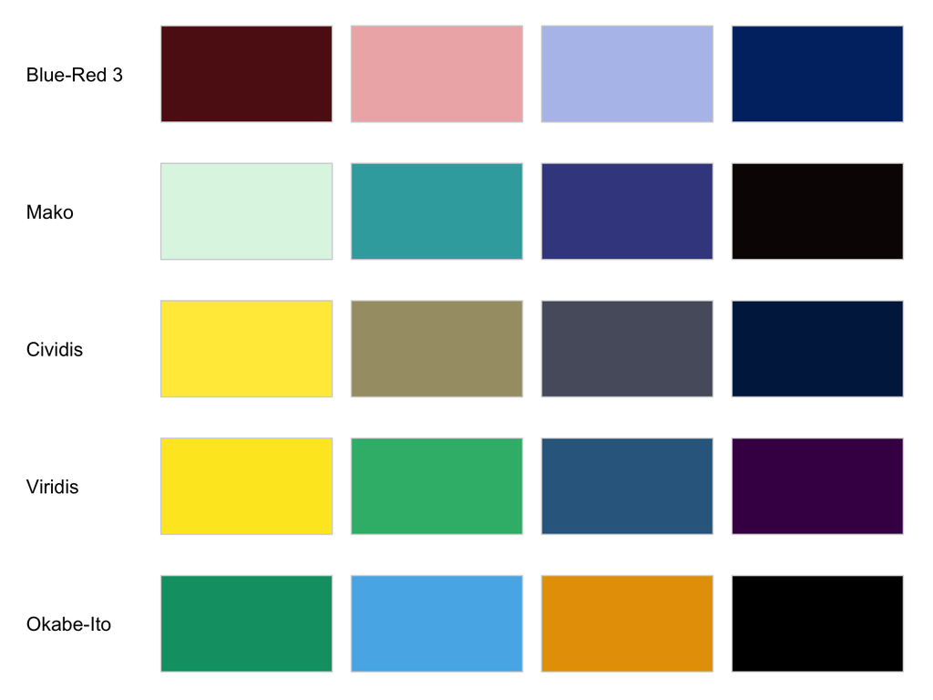

##### Colorblind Friendly Swatches for **5** Items

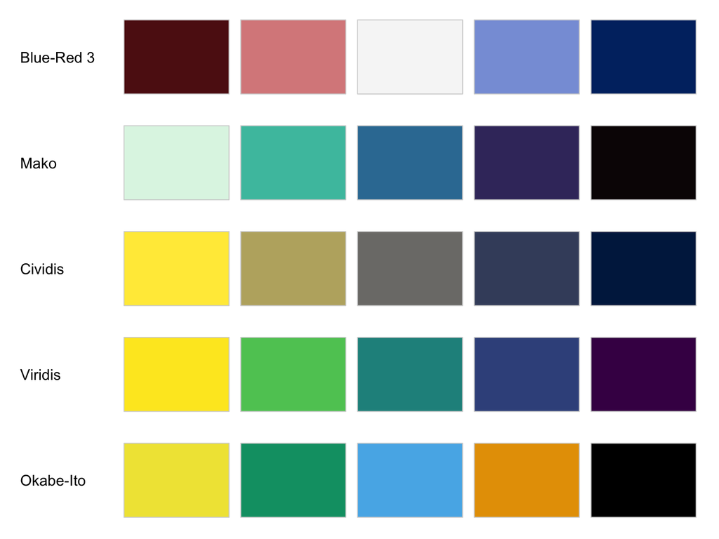

##### Colorblind Friendly Swatches for **6** Items

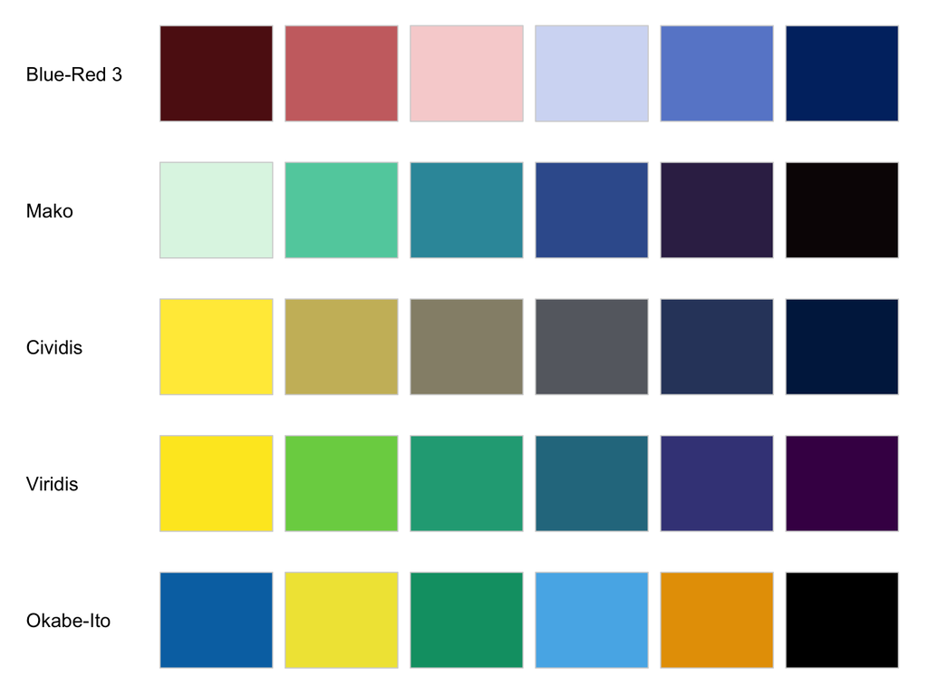

##### Colorblind Friendly Swatches for **7** Items

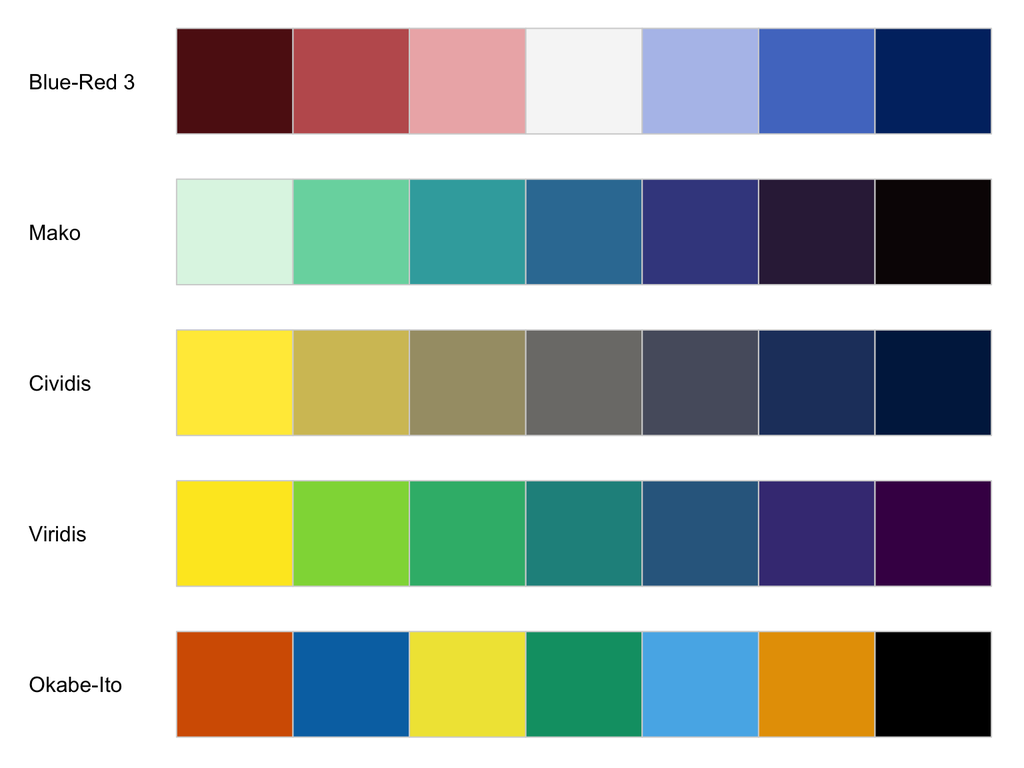